# Taller: Ajuste de Parámetros en Redes Neuronales (Caso Nexus-5)

Técnicas Cuantitativas Avanzadas II — UNIR

# Introducción

En este taller aprenderás a ajustar los parámetros de una red neuronal para predecir fallos en androides Nexus-5. Vamos a trabajar con un modelo simple en R (`nnet`) y explorar cómo los cambios en los hiperparámetros afectan al comportamiento del modelo.

# Instrucciones del taller

1. **Carga y analiza el dataset.**
2. **Configura los parámetros `size`, `decay` y `maxit`.**
3. **Ejecuta el modelo y evalúa su rendimiento.**
4. **Repite con distintas combinaciones de parámetros.**
5. **Completa el análisis comparativo y responde a las preguntas.**

# Cargar paquetes y datos

```r
# Cargar datos directamente usando ruta relativa
nexus <- read.csv("nexus5_datos_1000.csv")

# Verificar que no hay NA antes de la normalización
if (any(is.na(nexus))) {
  stop("Hay valores NA en el dataset que deben ser manejados primero")
}

nexus <- nexus |>
  mutate(across(
    c(energia_restante, contacto_blade_runner, antiguedad, experiencia_acumulada),
    ~ (. - min(., na.rm = TRUE)) / (max(., na.rm = TRUE) - min(., na.rm = TRUE))
  )) |>
  mutate(
    sexo = as.factor(sexo),
    rebeldia = as.factor(rebeldia),
    fallo = as.factor(fallo)
  )

# Verificar que la transformación fue exitosa
if (any(is.na(nexus))) {
  stop("La normalización produjo valores NA")
}

x <- model.matrix(fallo ~ ., data = nexus)[, -1]
y <- class.ind(nexus$fallo)
```

# Ajuste de hiperparámetros

## Parámetros disponibles

| Parámetro | Descripción | Valores recomendados |
| --- | --- | --- |
| `size` | Nº de neuronas en la capa oculta | 1–10 para modelos simples |
| `decay` | Penalización (regularización) para evitar sobreajuste | 0.001–0.1 |
| `maxit` | Iteraciones máximas para entrenamiento | 100–1000 |

## Parámetros actuales (modifícalos a discreción)

```r
# MODIFICA AQUÍ
param_size <- 5
param_decay <- 0.01
param_maxit <- 300
```

# Entrenamiento del modelo

```r
set.seed(42)
modelo <- nnet(x, y,
  size = param_size,
  decay = param_decay,
  maxit = param_maxit,
  softmax = TRUE
)
```

# Interpretación de Métricas

Antes de evaluar el modelo, es importante entender qué significan las métricas que vamos a utilizar:

## Matriz de Confusión

La matriz de confusión nos muestra: - **Verdaderos Positivos (VP)**: Casos correctamente identificados como fallos - **Falsos Positivos (FP)**: Casos incorrectamente clasificados como fallos - **Verdaderos Negativos (VN)**: Casos correctamente identificados como no fallos - **Falsos Negativos (FN)**: Casos incorrectamente clasificados como no fallos

## Métricas Principales

- **Precisión (Accuracy)**: Proporción total de predicciones correctas
  - Fórmula: (VP + VN) / (VP + VN + FP + FN)
  - Interpretación: Valores más altos indican mejor rendimiento general
- **Sensibilidad (Recall)**: Proporción de fallos reales que fueron correctamente identificados
  - Fórmula: VP / (VP + FN)
  - Interpretación: Importante cuando queremos minimizar falsos negativos
- **Especificidad**: Proporción de no fallos correctamente identificados
  - Fórmula: VN / (VN + FP)
  - Interpretación: Importante cuando queremos minimizar falsos positivos

## Curva ROC y AUC

- **Curva ROC**: Muestra la relación entre la tasa de verdaderos positivos (sensibilidad) y la tasa de falsos positivos (1-especificidad)
- **AUC (Area Under Curve)**:
  - Rango: 0 a 1
  - Interpretación:
    - 0.5: Modelo aleatorio
    - 0.7-0.8: Bueno
    - 0.8-0.9: Muy bueno
    - Por encima de 0.9: Excelente

## Sobreajuste

El sobreajuste se manifiesta cuando: - Alta precisión en datos de entrenamiento - Baja precisión en datos nuevos - Curva ROC muy optimista en entrenamiento - Grandes diferencias entre métricas de entrenamiento y validación

# Evaluación del modelo

```r
pred <- predict(modelo, x)[, 2]
pred_clase <- ifelse(pred > 0.5, 1, 0)
real <- as.numeric(nexus$fallo) - 1

confusionMatrix(factor(pred_clase), factor(real))
```

```
## Confusion Matrix and Statistics
##
##           Reference
## Prediction   0   1
##          0 274 119
##          1 212 395
##
##                Accuracy : 0.669
##                  95% CI : (0.6389, 0.6981)
##     No Information Rate : 0.514
##     P-Value [Acc > NIR] : < 2.2e-16
##
##                   Kappa : 0.334
##
##  Mcnemar's Test P-Value : 4.264e-07
##
##             Sensitivity : 0.5638
##             Specificity : 0.7685
##          Pos Pred Value : 0.6972
##          Neg Pred Value : 0.6507
##              Prevalence : 0.4860
##          Detection Rate : 0.2740
##    Detection Prevalence : 0.3930
##       Balanced Accuracy : 0.6661
##
##        'Positive' Class : 0
##
```

## Curva ROC

```r
roc_obj <- roc(real, pred)
```

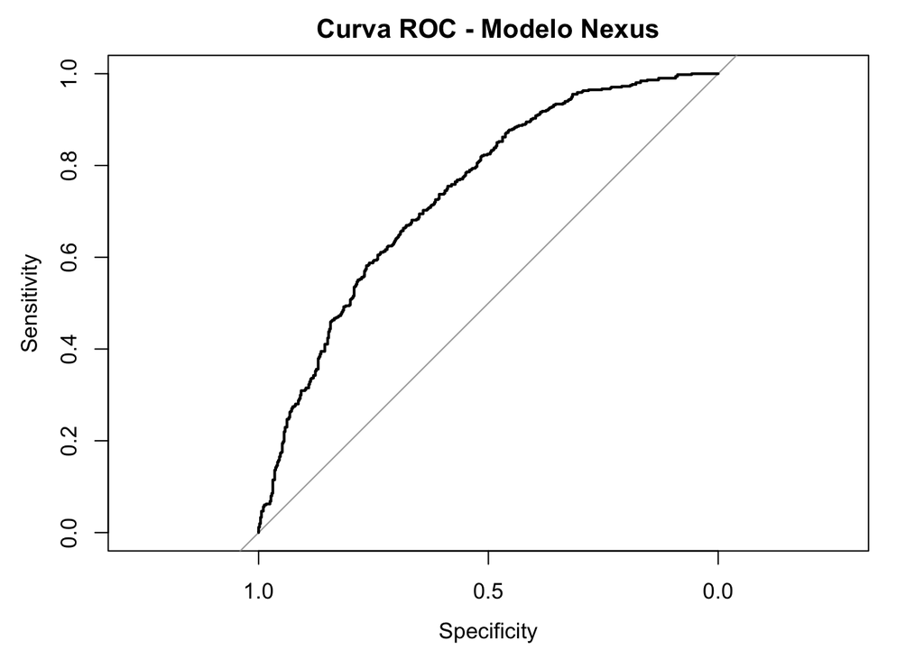

```r
plot(roc_obj, main = "Curva ROC - Modelo Nexus")
```

```r
auc(roc_obj)
```

```
## Area under the curve: 0.7402
```

# Visualización

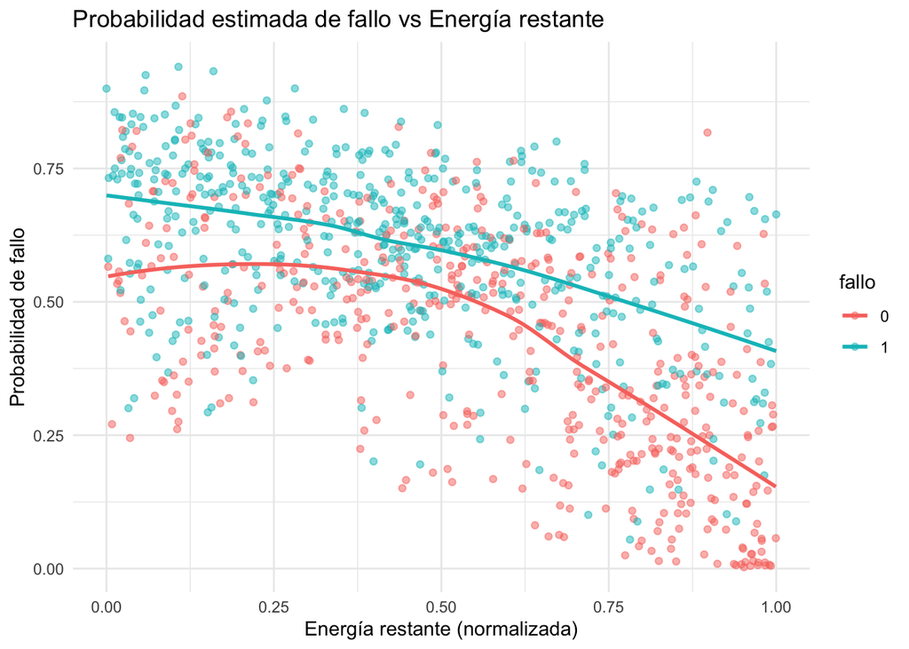

```r
nexus$prob_fallo <- pred

ggplot(nexus, aes(x = energia_restante, y = prob_fallo, color = fallo)) +
  geom_point(alpha = 0.5) +
  geom_smooth(method = "loess", se = FALSE) +
  labs(
    title = "Probabilidad estimada de fallo vs Energía restante",
    x = "Energía restante (normalizada)",
    y = "Probabilidad de fallo"
  ) +
  theme_minimal()
```

# Actividad: Comparación de modelos

Completa esta tabla a mano o en un archivo aparte:

| Modelo | size | decay | maxit | AUC | Precisión | ¿Sobreajuste? | Comentario |
| --- | --- | --- | --- | --- | --- | --- | --- |
| 1 |  |  |  |  |  |  |  |
| 2 |  |  |  |  |  |  |  |
| 3 |  |  |  |  |  |  |  |

# Análisis Comparativo de Modelos

Vamos a crear una función para evaluar diferentes combinaciones de hiperparámetros de manera sistemática:

```r
evaluar_modelo <- function(size, decay, maxit) {
  set.seed(42)
  modelo <- nnet(x, y,
    size = size,
    decay = decay,
    maxit = maxit,
    softmax = TRUE
  )

  pred <- predict(modelo, x)[, 2]
  pred_clase <- ifelse(pred > 0.5, 1, 0)
  real <- as.numeric(nexus$fallo) - 1

  # Calcular métricas
  cm <- confusionMatrix(factor(pred_clase), factor(real))
  roc_obj <- roc(real, pred)

  # Devolver resultados como vector
  c(
    size = size,
    decay = decay,
    maxit = maxit,
    accuracy = as.numeric(cm$overall["Accuracy"]),
    sensitivity = as.numeric(cm$byClass["Sensitivity"]),
    specificity = as.numeric(cm$byClass["Specificity"]),
    auc = as.numeric(auc(roc_obj))
  )
}

# Definir combinaciones a probar
combinaciones <- expand.grid(
  size = c(2, 5, 10),
  decay = c(0.001, 0.01, 0.1),
  maxit = c(100, 300, 500)
)

# Evaluar todas las combinaciones
resultados <- t(sapply(1:nrow(combinaciones), function(i) {
  with(combinaciones[i, ], evaluar_modelo(size, decay, maxit))
}))
# Convertir a data frame
resultados_df <- as.data.frame(resultados)

# Ordenar por AUC (de mayor a menor)
resultados_df <- resultados_df[order(resultados_df$auc, decreasing = TRUE), ]

# Mostrar resultados
knitr::kable(resultados_df,
  digits = 3,
  caption = "Comparativa de Modelos"
)
```

Comparativa de Modelos

|  | size | decay | maxit | accuracy | sensitivity | specificity | auc |
| --- | --- | --- | --- | --- | --- | --- | --- |
| 12 | 10 | 0.001 | 300 | 0.722 | 0.671 | 0.770 | 0.791 |
| 21 | 10 | 0.001 | 500 | 0.720 | 0.671 | 0.767 | 0.790 |
| 3 | 10 | 0.001 | 100 | 0.701 | 0.663 | 0.737 | 0.780 |
| 15 | 10 | 0.010 | 300 | 0.696 | 0.638 | 0.751 | 0.769 |
| 24 | 10 | 0.010 | 500 | 0.696 | 0.638 | 0.751 | 0.769 |
| 6 | 10 | 0.010 | 100 | 0.679 | 0.613 | 0.741 | 0.760 |
| 11 | 5 | 0.001 | 300 | 0.679 | 0.626 | 0.730 | 0.748 |
| 20 | 5 | 0.001 | 500 | 0.679 | 0.626 | 0.730 | 0.748 |
| 14 | 5 | 0.010 | 300 | 0.669 | 0.564 | 0.768 | 0.740 |
| 23 | 5 | 0.010 | 500 | 0.669 | 0.564 | 0.768 | 0.740 |
| 5 | 5 | 0.010 | 100 | 0.674 | 0.586 | 0.757 | 0.740 |
| 2 | 5 | 0.001 | 100 | 0.667 | 0.603 | 0.728 | 0.734 |
| 18 | 10 | 0.100 | 300 | 0.666 | 0.601 | 0.728 | 0.729 |
| 27 | 10 | 0.100 | 500 | 0.666 | 0.601 | 0.728 | 0.729 |
| 9 | 10 | 0.100 | 100 | 0.666 | 0.603 | 0.726 | 0.726 |
| 17 | 5 | 0.100 | 300 | 0.671 | 0.593 | 0.745 | 0.725 |
| 26 | 5 | 0.100 | 500 | 0.671 | 0.593 | 0.745 | 0.725 |
| 8 | 5 | 0.100 | 100 | 0.659 | 0.586 | 0.728 | 0.715 |
| 1 | 2 | 0.001 | 100 | 0.654 | 0.566 | 0.737 | 0.710 |
| 10 | 2 | 0.001 | 300 | 0.653 | 0.562 | 0.739 | 0.710 |
| 19 | 2 | 0.001 | 500 | 0.653 | 0.562 | 0.739 | 0.710 |
| 4 | 2 | 0.010 | 100 | 0.658 | 0.576 | 0.735 | 0.710 |
| 13 | 2 | 0.010 | 300 | 0.658 | 0.576 | 0.735 | 0.710 |
| 22 | 2 | 0.010 | 500 | 0.658 | 0.576 | 0.735 | 0.710 |
| 7 | 2 | 0.100 | 100 | 0.657 | 0.591 | 0.720 | 0.710 |
| 16 | 2 | 0.100 | 300 | 0.657 | 0.591 | 0.720 | 0.710 |
| 25 | 2 | 0.100 | 500 | 0.657 | 0.591 | 0.720 | 0.710 |

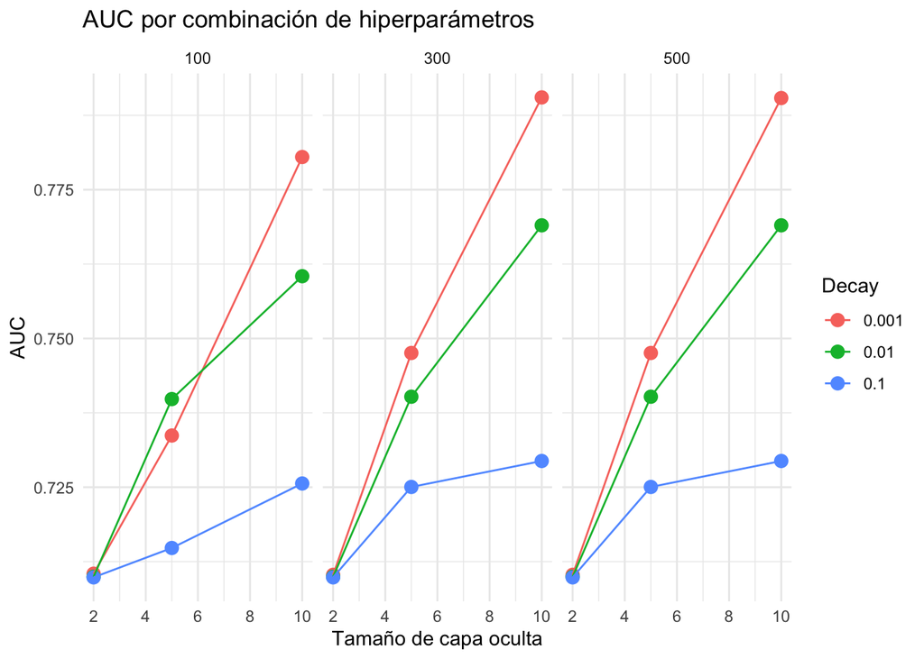

```r
# Visualizar resultados
ggplot(resultados_df, aes(x = size, y = auc, color = factor(decay))) +
  geom_point(size = 3) +
  geom_line(aes(group = decay)) +
  facet_wrap(~maxit) +
  labs(
    title = "AUC por combinación de hiperparámetros",
    x = "Tamaño de capa oculta",
    y = "AUC",
    color = "Decay"
  ) +
  theme_minimal()
```

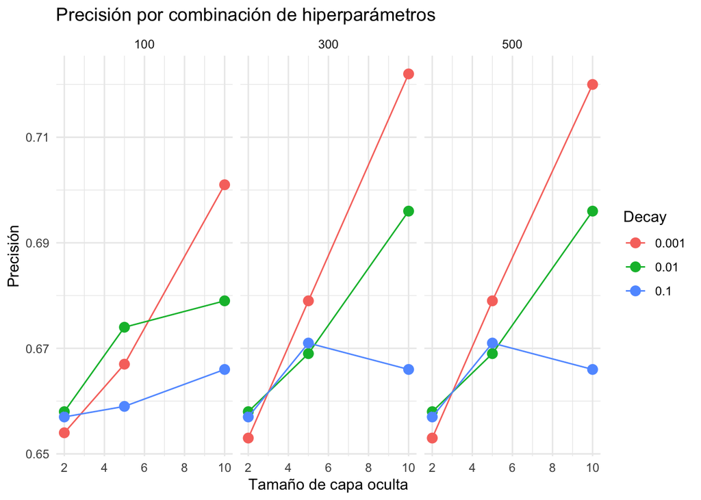

```r
# Análisis de sobreajuste
ggplot(resultados_df, aes(x = size, y = accuracy, color = factor(decay))) +
  geom_point(size = 3) +
  geom_line(aes(group = decay)) +
  facet_wrap(~maxit) +
  labs(
    title = "Precisión por combinación de hiperparámetros",
    x = "Tamaño de capa oculta",
    y = "Precisión",
    color = "Decay"
  ) +
  theme_minimal()
```

# Preguntas de reflexión

Basándote en los resultados del análisis comparativo, responde a las siguientes preguntas:

1. ¿Qué combinación ha dado mejor equilibrio entre simplicidad y rendimiento?
- Considera el tamaño de la capa oculta (`size`) y el valor de `decay`
- Evalúa el trade-off entre complejidad y rendimiento
2. ¿Cómo se manifiesta el sobreajuste en este modelo?
- Analiza la relación entre `size` y la precisión
- Observa cómo afecta el `decay` a la estabilidad del modelo
3. ¿Qué aprendiste sobre el parámetro `decay`?
- Evalúa su impacto en la regularización
- Considera su interacción con `size`
4. ¿Cómo afecta el tamaño de la capa oculta al modelo?
- Analiza la relación entre complejidad y rendimiento
- Identifica el punto de rendimientos decrecientes